# Аналитический отчет

2023-12-16

## Введение

Для анализа были взяты предварительно обработанные данные из трех источников: СберИндекс, ДомКлик и Росстат, представленные в открытом доступе и отображающие распределение социоэкономических показателей по регионам России. Итоговый объединенный датафрейм, взятый для анализа, включает 15 показателей (Итоговая таблица.xslx):

- Регион
- Месяц
- Квартал
- Индекс потребительской активности
- Доля безналичных платежей
- Количество внутренних туристов
- Общее количество одобренных заявок на кредит
- Доля онлайн-заявок на кредит
- Доля заявок на кредит в офисе банка
- Общее количество ипотечных сделок
- Доля сделок, первичное жилье
- Доля сделок, вторичное жилье
- Среднемесячная заработная плата
- Число активных абонентов беспроводного интернета
- Уровень безработицы населения

**Задачи исследования:**

- Проанализировать особенности распределения указанных выше показателей
- Выбрать среди регионов России наиболее перспективные для открытия филиалов *TrustUs*
- Выявить ключевые факторы, определяющие спрос населения на банковски услуги

На основании сравнительного анализ социально-экономических показателей выбрать наиболее перспективные регионы для открытия филиалов банка

# Разведывательный анализ:

```r
# Подгружаем библиотеки:
library(tidyverse)
library(readxl)
library(psych)
```

```r
# Загружаем данные:
dat <- read_xlsx("Итоговая таблица.xlsx")
dat$`Число активных абонентов беспроводного доступа к сети` <- as.numeric(dat$`Число активных абонентов беспроводного доступа к сети`)
dat$Месяц <- factor(dat$Месяц, ordered = TRUE,
                        levels = c("Январь", "Февраль", "Март",
                                                "Апрель", "Май", "Июнь", "Июль",
                                                "Август", "Сентябрь", "Октябрь",
                                                "Ноябрь", "Декабрь"))
dat$Квартал <- factor(dat$Квартал,
                         levels = c("Квартал 1", "Квартал 2", "Квартал 3", "Квартал 4"))

dat$`Всего одобренных заявок` <- factor(dat$`Всего одобренных заявок`,
                                               ordered = TRUE,
                                               levels = c("100 - 500",
                                                          "500 - 1 000",
                                                          "1 000 - 5 000",
                                                          "5 000 - 10 000",
                                                          "> 10 000"))
dat$`Всего ипотечных сделок` <- factor(dat$`Всего ипотечных сделок`,
                                          ordered = TRUE,
                                          levels = c("10 - 50",
                                                     "50 - 100",
                                                     "100 - 500",
                                                     "500 - 1 000",
                                                     "> 1 000"))
```

```r
# Выведем описательные статистики для показателей СберИндекс:
dat %>%
  select(`Индекс потребительской активности` : `Количество внутренних туристов`) %>%
  describe()
```

```
##                                   vars   n  mean    sd median trimmed   mad
## Индекс потребительской активности    1 912 65.51  8.80  67.00   66.20  7.41
## Доля безналичных платежей            2 912 52.33  7.67  53.25   53.22  5.86
## Количество внутренних туристов       3 912 -7.46 28.25  -4.54   -6.96 28.50
##                                      min   max  range  skew kurtosis   se
## Индекс потребительской активности  34.00 88.00  54.00 -0.73     0.61 0.29
## Доля безналичных платежей          16.00 66.10  50.10 -1.85     5.19 0.25
## Количество внутренних туристов    -85.47 86.14 171.61 -0.09    -0.18 0.94
```

Можно отметить, что три исследуемых показателя (Индекс потребительской активности, доля безналичных платежей, количество внутренних туристов) имеют высокий размах, т.е. значительную разницу между минимальными и максимальными значениями показателей. Вместе с этим, имеются небольшие различия между медианными и средними значениями, что может говорить о наличии нетипичных значений. Значения skew во всех стрех случаях < 0, что говорит о скошенности распределения влево.

Интересно отметить отрицательные значения медианы и среднего количества внутренних туристов, что может быть связано с противоэпидемическим режимом в 2020 г. И действительно, если посмотреть данные, отрицательные значения по большинству регионов появляются в апреле 2020 г, когда в полной мере были развернуты антиковидные ограничения.

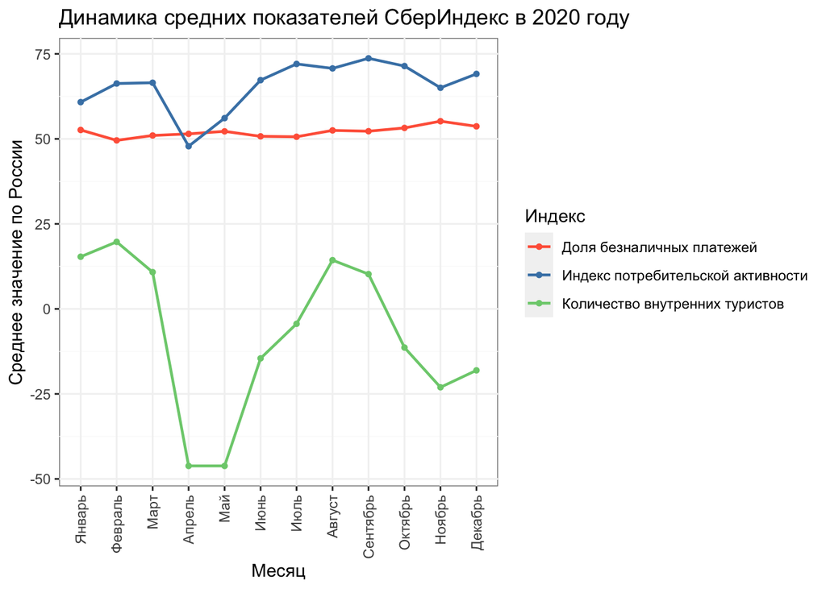

```r
## Построим график, отображающий динамику средних значений данных показателей по месяцам :
dat_mean <- dat %>%
  drop_na %>%
  group_by(Месяц) %>%
  summarise(`Индекс потребительской активности` = mean(`Индекс потребительской активности`),
            `Доля безналичных платежей` = mean(`Доля безналичных платежей`),
            `Количество внутренних туристов` = mean(`Количество внутренних туристов`))
dat_mean <- pivot_longer(data = dat_mean, cols = 2:4, names_to = "Индекс", values_to = "Значение")

dat_mean %>%
  ggplot(aes(x = Месяц, y = Значение, group = Индекс, color = Индекс)) +
  geom_line(size = 0.8) +
  geom_point(size = 1.2) +
  labs(title = "Динамика средних показателей СберИндекс в 2020 году",
       x = "Месяц",
       y = "Среднее значение по России") +
  scale_colour_manual(values = c("tomato", "steelblue", "palegreen3")) +
  theme(axis.text.x = element_text(angle = 90, vjust = 0.5, hjust=1),
        panel.background = element_rect(fill = "white", colour = "grey50"),
        panel.grid.major = element_line(color = "grey95"),
        panel.grid.minor = element_line(color = "grey98"))
```

Графики динамики также отражают падение индекса потребительской активности и количества внутренних туристов весной 2020 г. При этом не уменьшилась доля безналичных платежей, что тоже кажется логичным.

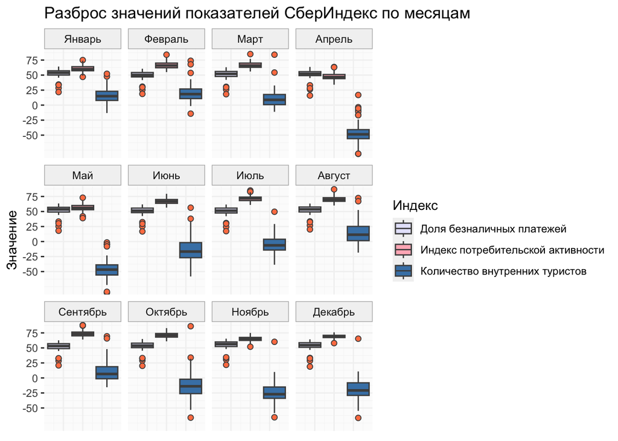

```r
dat_long <- dat %>%
  drop_na %>%
  select(1:6) %>%
  pivot_longer(cols = 4:6,names_to = "Индекс", values_to = "Значение")

dat_long %>%
  ggplot(aes(y = Значение, group = Индекс, fill = Индекс)) +
  geom_boxplot(color = "gray30",
               outlier.fill = "coral",
               outlier.shape = 21,
               outlier.size = 1.8) +
  scale_fill_manual(values = c("lavender", "lightpink", "steelblue")) +
  facet_wrap(facets = ~Месяц) +
  scale_y_continuous(breaks = c(-50, -25, 0, 25, 50, 75)) +
  coord_cartesian(ylim = c(-80, 85)) +
  labs(title = "Разброс значений показателей СберИндекс по месяцам") +
  theme(axis.ticks.x = element_blank(),
        axis.text.x = element_blank(),
        panel.background = element_rect(fill = "grey99"),
        panel.grid.major = element_line(color = "grey95"),
        panel.grid.minor = element_line(color = "grey97"),
        strip.background = element_rect(color = "grey70", fill = "grey95"))
```

Графики с усами также позволяют отследить динамику по месяцам для выбранных показателей, а таккже отображают большое количество нетипичных значений, которые следует изучить подробнее.

```r
# Поиск нетипичных значений:
dat_clean <- dat %>%
  drop_na()

get_outliers <- function(x){
  iqr <- IQR(x)
  q1 <- quantile(x, 0.25)
  q3 <- quantile(x, 0.75)
  lower_b <- q1 - 1.5 * iqr
  upper_b <- q3 + 1.5 * iqr
  extra <- x[x < lower_b | x > upper_b]
  return(extra)
}

consume_out <- dat[dat$`Индекс потребительской активности` %in% get_outliers(dat_clean$`Индекс потребительской активности`), 1:4]
cashless_out <- dat[dat$`Доля безналичных платежей` %in% get_outliers(dat_clean$`Доля безналичных платежей`), c(1:3, 5)]
voyage_out <- dat[dat$`Количество внутренних туристов` %in% get_outliers(dat_clean$`Количество внутренних туристов`), c(1:3, 6)]

dat_out <- full_join(consume_out, cashless_out)
dat_out <- full_join(dat_out, voyage_out)
dat_out <- dat_out %>%
  pivot_longer(cols = `Индекс потребительской активности` : `Количество внутренних туристов`, names_to = "Индекс", values_to = "Значение")
dat_out <- dat_out %>%
  drop_na()
```

Рассмотрим, каким месяцам соотвествует наибольшее количество нетипичных значений:

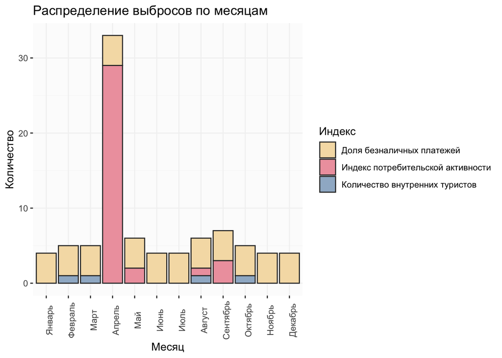

```r
# Визуализируем нетипичные значения:
dat_out %>%
  ggplot(aes(x = Месяц, fill = Индекс)) +
  geom_bar(color = "grey20") +
  labs(title = "Распределение выбросов по месяцам",
       x = "Месяц",
       y = "Количество") +
  scale_fill_manual(values = c("wheat", "lightpink2", "slategray3")) +
  theme(axis.text.x = element_text(angle = 90),
        panel.background = element_rect(fill = "grey99"),
        panel.grid.major = element_line(color = "grey95"),
        panel.grid.minor = element_line(color = "grey97"))
```

Нетипичные значения в показателе “Доля безналичных платежей” равномерно распределены и встречаются в каждом месяце. Соответственно, это сможет быть связано не периодом, а с определенными регионами. Нетипичные значения количества внтутренних туристов встречаются в феврале, марте, августе и октябре. Вероятно. внутренний туризм в период с апреля по август был затруднен вследствие ограничений. Выбросы в показателе “Индекс потребительской активности” встречаются в четырех месяцах и с максимумом в апреле, что тоже укладывается в предположение о влиянии ограничений, связанных с пандемией COVID-19.

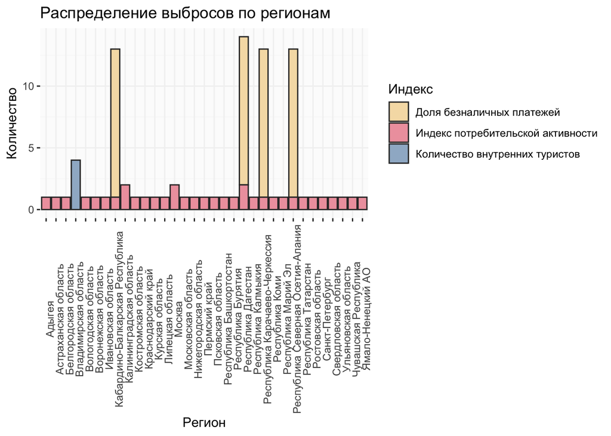

```r
# По регионам:
dat_out %>%
  ggplot(aes(x = Регион, fill = Индекс)) +
  geom_bar(color = "grey20") +
  labs(title = "Распределение выбросов по регионам",
       x = "Регион",
       y = "Количество") +
  scale_fill_manual(values = c("wheat", "lightpink2", "slategray3")) +
  theme(axis.text.x = element_text(angle = 90),
        panel.background = element_rect(fill = "grey99"),
        panel.grid.major = element_line(color = "grey95"),
        panel.grid.minor = element_line(color = "grey97"))
```

Если посмотреть на распределение нетипичных значений по регионам, можно заметить, что выбросы среди значений индекса потребительской активности распределены равномерно, за исключением трех регионов. Так как нетипичные значения в апреле по этому показателю ниже граничного значения (q1 - 1.5 * IQR), то , вероятно, потребительская активность в этих регионах потсрадала наиболее сильно. Нетипичные значения доли безналичных платежей соответствуют четырем регионам: Кабардино-Балкарской Республике, Республике Дагестан, республике Карачаево-Черкессии, Республике Северной Осетии-Алании. Так как нетипично низкие значения этого показателя распределены равномерно по месяцам, можно предположить, что в этих регионах более распространены платежи наличными.

```r
# Находим топ-30 регионов по индексу потребительской активности:
top_consume <- dat %>%
  drop_na %>%
  group_by(Регион) %>%
  summarise(mean_consume = mean(`Индекс потребительской активности`)) %>%
  arrange(desc(mean_consume)) %>%
  slice_head(n = 30)
```

```r
# Находим топ-30 регионов по доле безналичных платежей:
top_cashless <- dat %>%
  drop_na %>%
  group_by(Регион) %>%
  summarise(mean_cashless = mean(`Доля безналичных платежей`)) %>%
  arrange(desc(mean_cashless)) %>%
  slice_head(n = 30)
```

```r
# Находим регионы, общие для обоих датафреймов:
top_both <- inner_join(top_consume, top_cashless, by = "Регион")
top_both
```

```
## # A tibble: 15 × 3
##    Регион                  mean_consume mean_cashless
##    <chr>                          <dbl>         <dbl>
##  1 Калининградская область         74.8          58.9
##  2 Воронежская область             73.4          54.5
##  3 Тюменская область               73.2          60.0
##  4 Хабаровский край                71            57.7
##  5 Кировская область               70.3          57.7
##  6 Иркутская область               68.5          56.6
##  7 Свердловская область            68.1          57.3
##  8 Самарская область               67.7          54.9
##  9 Москва                          67.7          57.1
## 10 Нижегородская область           67.6          55.7
## 11 Республика Башкортостан         67.4          55.1
## 12 Камчатский край                 67.3          60.4
## 13 Кемеровская область             66.5          55.3
## 14 Томская область                 66.5          59.0
## 15 Удмуртская Республика           66.4          57.4
```

```r
# Выберем в основном датафрейме только регионы, попавшие в топ:
top_both <- dat[dat$Регион %in% top_both$Регион, ]
```

```r
# Среди полученных регионов оставим только те, в которых индекс внутреннего туризма принимал значения выше 0 не менее чем в течение 5 месяцев:
top_both <- top_both %>%
  mutate(tourindex = ifelse(`Количество внутренних туристов` > 0, 1, 0), .after = `Количество внутренних туристов`)

top_tour <- top_both %>%
  group_by(Регион) %>%
  summarise(tour_sum = sum(tourindex)) %>%
  filter(tour_sum >= 5)
```

Выберем регионы, лидирующие по всем трем показателям:

```r
# Выберем из основного датафрейма регионы, лидирующие по всем трем показателями:
top <- dat[dat$Регион %in% top_tour$Регион, ]
unique(top$Регион)
```

```
## [1] "Воронежская область"     "Калининградская область"
## [3] "Камчатский край"         "Кировская область"
## [5] "Нижегородская область"   "Самарская область"
```

Рассмотрим, в какие месяцы наблюдаются максимальные значения исследуемых нами показателей: